# More mov CV

# 17 Stock mixing

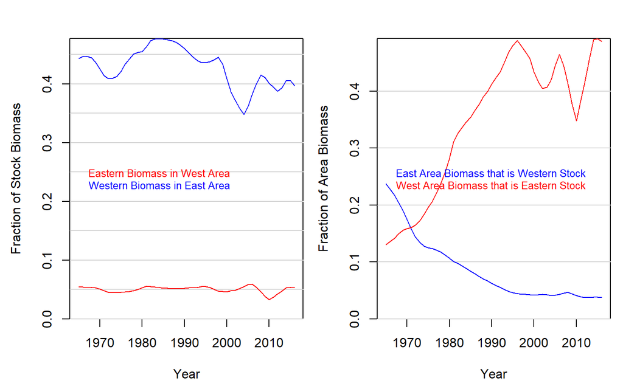

Figure 16. Predicted stock mixing (averaged over seasons, summed over areas). On the left is the degree to which each stock has been distributed in the opposite ocean area over time. One the right is the fraction of Eastern Stock biomass found in the East/West areas over time (stock composition over time).

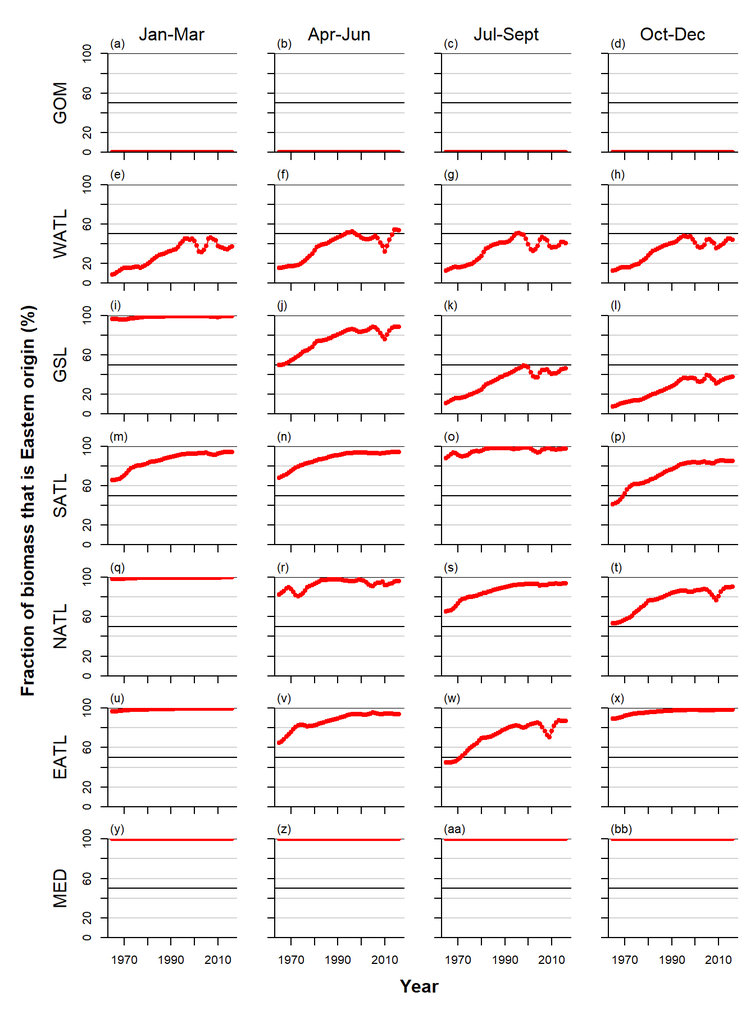

Figure 17. Predicted stock mixing by year, season and area. The red line is the fraction (%) of stock biomass that is Eastern.